# Projet_Gaudin_Le-Meur

2024-03-18

```r
library(knitr)
library(readxl)
library(corrplot)
library(FactoMineR)
library(factoextra)
library(Hmisc)
```

## Projet : Vins

FIchier : vins.xls

La consommation de plusieurs types de vins (exprimee en KiloLitres/an) est observee dans plusieurs pays.

Objectif : Analyse descriptive multivariée, classification des pays.

```r
vins <- read_excel("vins.xls")
vins=t(vins)
d<-vins[2:9,]
colnames(d)=vins[1,1:18]
d<-as.data.frame(d)
nomcol=colnames(d)
for (i in nomcol){
  d[,i]=as.integer(d[,i])
}

kable(str(d), format="markdown")
```

```
## 'data.frame':    8 obs. of  18 variables:
##  $ CHMPAGNE       : int  7069 3786 12578 8037 13556 9664 10386 206
##  $ MOUSSEAU_AOC   : int  2436 586 2006 30 1217 471 997 51
##  $ MOUSSEAU_SIMPLE: int  3066 290 10439 1413 7214 112 3788 330
##  $ ALSACE         : int  2422 1999 17183 57 1127 600 408 241
##  $ GIRONDE        : int  22986 22183 21023 56 30025 6544 13114 3447
##  $ BOJOLAIS       : int  17465 19840 72977 2364 39919 17327 17487 2346
##  $ BORDEAUX       : int  3784 2339 4828 98 7885 3191 11791 1188
##  $ RHON           : int  7950 10537 7552 24 8172 11691 1369 1798
##  $ ANJOU          : int  2587 600 2101 0 7582 143 872 131
##  $ AOC_AUTRES     : int  17200 22806 15979 50 20004 1279 4016 944
##  $ VDQS           : int  1976 1029 1346 0 2258 212 1017 487
##  $ AUTRE_VDQS     : int  38747 19151 191140 7992 101108 1029 26192 38503
##  $ PROVENCE       : int  1375 1150 2514 0 284 401 9 236
##  $ MUSCAT         : int  2016 2908 1529 0 12891 18 716 653
##  $ RHONE          : int  785 1648 1009 6 775 643 542 35
##  $ AOC_FORT       : int  160 246 135 8 1177 26 7 0
##  $ AUTRE_FORT     : int  24 1533 160 0 480 0 0 0
##  $ TRES_FORT      : int  2415 74 208 8 1705 12 36 47
```

## Analyse univariée

ON restreint la hauteur pour mieux visualiser, ne pas oublier qu’il y a des valeurs extrêmes

```r
kable(summary(d[1:9]), format="markdown")
```

|  | CHMPAGNE | MOUSSEAU_AOC | MOUSSEAU_SIMPLE | ALSACE | GIRONDE | BOJOLAIS | BORDEAUX | RHON | ANJOU |
| --- | --- | --- | --- | --- | --- | --- | --- | --- | --- |
|  | Min. : 206 | Min. : 30.0 | Min. : 112 | Min. : 57.0 | Min. : 56 | Min. : 2346 | Min. : 98 | Min. : 24 | Min. : 0 |
|  | 1st Qu.: 6248 | 1st Qu.: 366.0 | 1st Qu.: 320 | 1st Qu.: 366.2 | 1st Qu.: 5770 | 1st Qu.:13586 | 1st Qu.: 2051 | 1st Qu.: 1691 | 1st Qu.: 140 |
|  | Median : 8850 | Median : 791.5 | Median : 2240 | Median : 863.5 | Median :17068 | Median :17476 | Median : 3488 | Median : 7751 | Median : 736 |
|  | Mean : 8160 | Mean : 974.2 | Mean : 3332 | Mean : 3004.6 | Mean :14922 | Mean :23716 | Mean : 4388 | Mean : 6137 | Mean :1752 |
|  | 3rd Qu.:10934 | 3rd Qu.:1414.2 | 3rd Qu.: 4644 | 3rd Qu.: 2104.8 | 3rd Qu.:22384 | 3rd Qu.:24860 | 3rd Qu.: 5592 | 3rd Qu.: 8763 | 3rd Qu.:2222 |
|  | Max. :13556 | Max. :2436.0 | Max. :10439 | Max. :17183.0 | Max. :30025 | Max. :72977 | Max. :11791 | Max. :11691 | Max. :7582 |

```r
kable(summary(d[10:18]), format="markdown")
```

|  | AOC_AUTRES | VDQS | AUTRE_VDQS | PROVENCE | MUSCAT | RHONE | AOC_FORT | AUTRE_FORT | TRES_FORT |
| --- | --- | --- | --- | --- | --- | --- | --- | --- | --- |
|  | Min. : 50 | Min. : 0.0 | Min. : 1029 | Min. : 0.0 | Min. : 0.0 | Min. : 6.0 | Min. : 0.00 | Min. : 0.0 | Min. : 8.0 |
|  | 1st Qu.: 1195 | 1st Qu.: 418.2 | 1st Qu.: 16361 | 1st Qu.: 179.2 | 1st Qu.: 494.2 | 1st Qu.: 415.2 | 1st Qu.: 7.75 | 1st Qu.: 0.0 | 1st Qu.: 30.0 |
|  | Median : 9998 | Median :1023.0 | Median : 32348 | Median : 342.5 | Median : 1122.5 | Median : 709.0 | Median : 80.50 | Median : 12.0 | Median : 60.5 |
|  | Mean :10285 | Mean :1040.6 | Mean : 52983 | Mean : 746.1 | Mean : 2591.4 | Mean : 680.4 | Mean : 219.88 | Mean : 274.6 | Mean : 563.1 |
|  | 3rd Qu.:17901 | 3rd Qu.:1503.5 | 3rd Qu.: 54337 | 3rd Qu.:1206.2 | 3rd Qu.: 2239.0 | 3rd Qu.: 841.0 | 3rd Qu.: 181.50 | 3rd Qu.: 240.0 | 3rd Qu.: 582.2 |
|  | Max. :22806 | Max. :2258.0 | Max. :191140 | Max. :2514.0 | Max. :12891.0 | Max. :1648.0 | Max. :1177.00 | Max. :1533.0 | Max. :2415.0 |

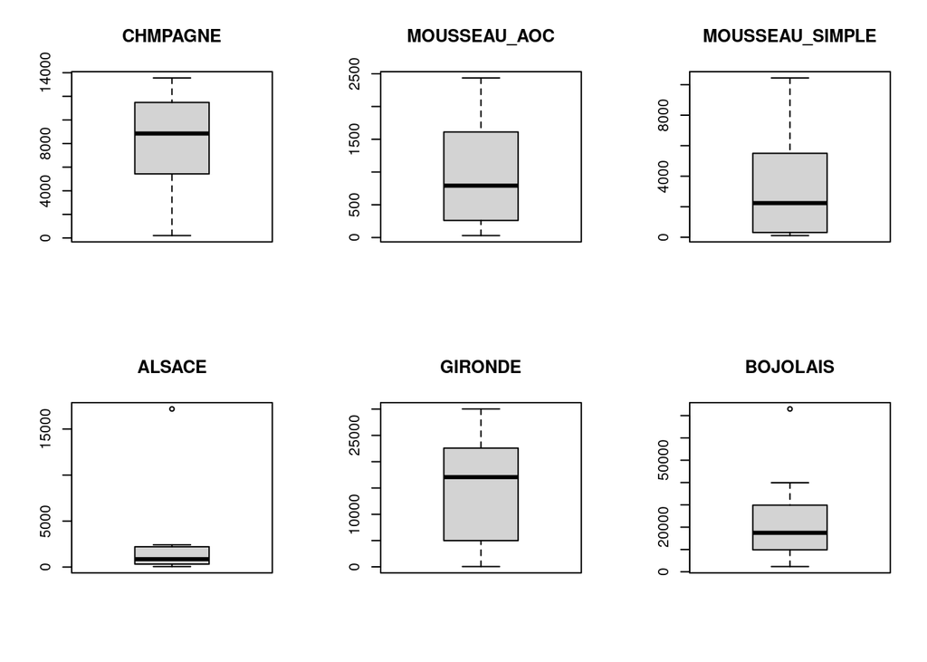

```r
par(mfrow = c(2,3))
for (i in 1:6){
  boxplot(d[i],main=names(d[i]))
}
```

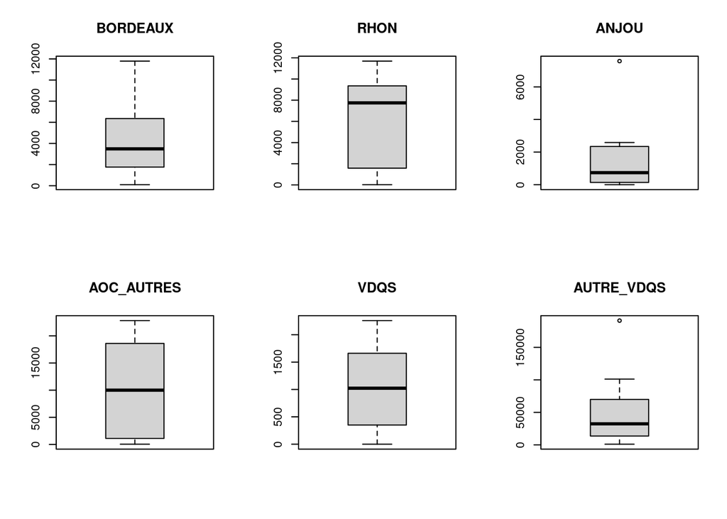

```r
par(mfrow = c(2,3))
for (i in 7:12){
  boxplot(d[i],main=names(d[i]))
}
```

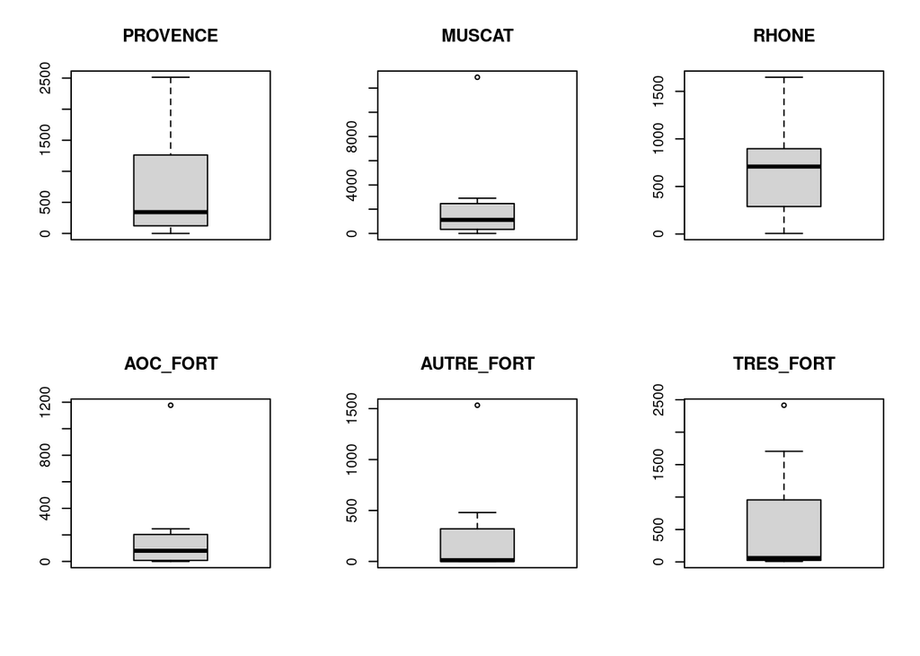

```r
par(mfrow = c(2,3))
for (i in 13:18){
  boxplot(d[i],main=names(d[i]))
}
```

## Analyse multivariée

```r
cor=cov.wt(d, method="ML", cor=TRUE)$cor
cor<-as.data.frame(cor)
kable(round(cor[1:9],2), format="markdown")
```

|  | CHMPAGNE | MOUSSEAU_AOC | MOUSSEAU_SIMPLE | ALSACE | GIRONDE | BOJOLAIS | BORDEAUX | RHON | ANJOU |
| --- | --- | --- | --- | --- | --- | --- | --- | --- | --- |
| CHMPAGNE | 1.00 | 0.46 | 0.74 | 0.39 | 0.43 | 0.66 | 0.60 | 0.21 | 0.58 |
| MOUSSEAU_AOC | 0.46 | 1.00 | 0.66 | 0.57 | 0.72 | 0.63 | 0.38 | 0.36 | 0.47 |
| MOUSSEAU_SIMPLE | 0.74 | 0.66 | 1.00 | 0.77 | 0.59 | 0.91 | 0.48 | 0.08 | 0.62 |
| ALSACE | 0.39 | 0.57 | 0.77 | 1.00 | 0.34 | 0.89 | 0.05 | 0.22 | 0.10 |
| GIRONDE | 0.43 | 0.72 | 0.59 | 0.34 | 1.00 | 0.63 | 0.46 | 0.56 | 0.78 |
| BOJOLAIS | 0.66 | 0.63 | 0.91 | 0.89 | 0.63 | 1.00 | 0.34 | 0.41 | 0.48 |
| BORDEAUX | 0.60 | 0.38 | 0.48 | 0.05 | 0.46 | 0.34 | 1.00 | -0.04 | 0.45 |
| RHON | 0.21 | 0.36 | 0.08 | 0.22 | 0.56 | 0.41 | -0.04 | 1.00 | 0.28 |
| ANJOU | 0.58 | 0.47 | 0.62 | 0.10 | 0.78 | 0.48 | 0.45 | 0.28 | 1.00 |
| AOC_AUTRES | 0.21 | 0.61 | 0.45 | 0.36 | 0.93 | 0.56 | 0.18 | 0.60 | 0.60 |
| VDQS | 0.41 | 0.79 | 0.62 | 0.25 | 0.93 | 0.53 | 0.51 | 0.35 | 0.84 |
| AUTRE_VDQS | 0.51 | 0.58 | 0.93 | 0.88 | 0.53 | 0.93 | 0.24 | 0.15 | 0.50 |
| PROVENCE | 0.18 | 0.71 | 0.57 | 0.89 | 0.50 | 0.76 | -0.10 | 0.47 | 0.08 |
| MUSCAT | 0.43 | 0.23 | 0.44 | -0.06 | 0.72 | 0.35 | 0.37 | 0.29 | 0.95 |
| RHONE | 0.15 | 0.43 | 0.22 | 0.36 | 0.74 | 0.50 | 0.17 | 0.76 | 0.22 |
| AOC_FORT | 0.46 | 0.22 | 0.45 | -0.05 | 0.71 | 0.36 | 0.34 | 0.33 | 0.95 |
| AUTRE_FORT | -0.21 | -0.08 | -0.12 | -0.01 | 0.49 | 0.11 | -0.10 | 0.48 | 0.12 |
| TRES_FORT | 0.23 | 0.70 | 0.28 | -0.05 | 0.65 | 0.14 | 0.18 | 0.28 | 0.70 |

```r
kable(round(cor[10:18],2), format="markdown")
```

|  | AOC_AUTRES | VDQS | AUTRE_VDQS | PROVENCE | MUSCAT | RHONE | AOC_FORT | AUTRE_FORT | TRES_FORT |
| --- | --- | --- | --- | --- | --- | --- | --- | --- | --- |
| CHMPAGNE | 0.21 | 0.41 | 0.51 | 0.18 | 0.43 | 0.15 | 0.46 | -0.21 | 0.23 |
| MOUSSEAU_AOC | 0.61 | 0.79 | 0.58 | 0.71 | 0.23 | 0.43 | 0.22 | -0.08 | 0.70 |
| MOUSSEAU_SIMPLE | 0.45 | 0.62 | 0.93 | 0.57 | 0.44 | 0.22 | 0.45 | -0.12 | 0.28 |
| ALSACE | 0.36 | 0.25 | 0.88 | 0.89 | -0.06 | 0.36 | -0.05 | -0.01 | -0.05 |
| GIRONDE | 0.93 | 0.93 | 0.53 | 0.50 | 0.72 | 0.74 | 0.71 | 0.49 | 0.65 |
| BOJOLAIS | 0.56 | 0.53 | 0.93 | 0.76 | 0.35 | 0.50 | 0.36 | 0.11 | 0.14 |
| BORDEAUX | 0.18 | 0.51 | 0.24 | -0.10 | 0.37 | 0.17 | 0.34 | -0.10 | 0.18 |
| RHON | 0.60 | 0.35 | 0.15 | 0.47 | 0.29 | 0.76 | 0.33 | 0.48 | 0.28 |
| ANJOU | 0.60 | 0.84 | 0.50 | 0.08 | 0.95 | 0.22 | 0.95 | 0.12 | 0.70 |
| AOC_AUTRES | 1.00 | 0.80 | 0.46 | 0.60 | 0.60 | 0.84 | 0.60 | 0.69 | 0.54 |
| VDQS | 0.80 | 1.00 | 0.52 | 0.39 | 0.73 | 0.47 | 0.71 | 0.21 | 0.82 |
| AUTRE_VDQS | 0.46 | 0.52 | 1.00 | 0.71 | 0.35 | 0.26 | 0.35 | -0.03 | 0.17 |
| PROVENCE | 0.60 | 0.39 | 0.71 | 1.00 | -0.06 | 0.60 | -0.05 | 0.21 | 0.18 |
| MUSCAT | 0.60 | 0.73 | 0.35 | -0.06 | 1.00 | 0.27 | 1.00 | 0.33 | 0.56 |
| RHONE | 0.84 | 0.47 | 0.26 | 0.60 | 0.27 | 1.00 | 0.27 | 0.80 | 0.15 |
| AOC_FORT | 0.60 | 0.71 | 0.35 | -0.05 | 1.00 | 0.27 | 1.00 | 0.33 | 0.55 |
| AUTRE_FORT | 0.69 | 0.21 | -0.03 | 0.21 | 0.33 | 0.80 | 0.33 | 1.00 | -0.06 |
| TRES_FORT | 0.54 | 0.82 | 0.17 | 0.18 | 0.56 | 0.15 | 0.55 | -0.06 | 1.00 |

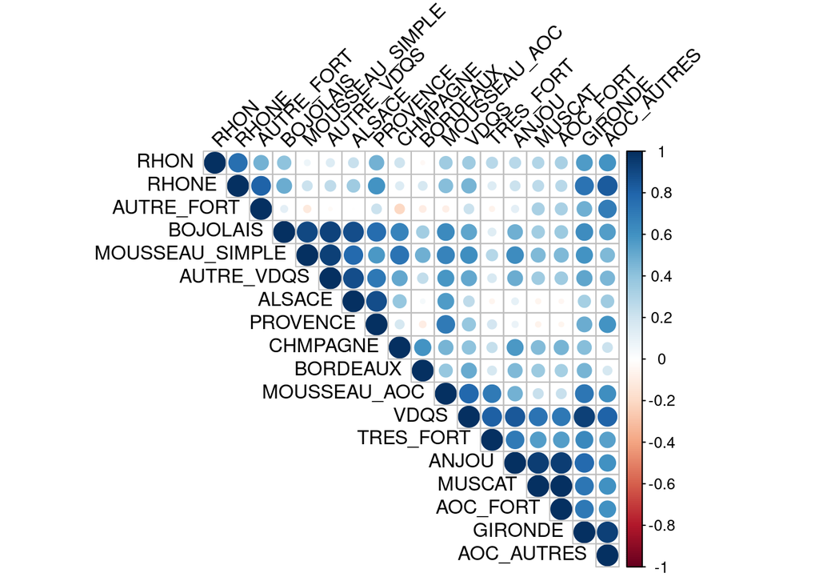

```r
corr<-cor(d, method="pearson")
corrplot(corr, type="upper", order="hclust", tl.col="black", tl.srt=45)
```

```r
A = PCA(d, scale.unit=TRUE,graph=FALSE)
eig=A$eig

kable(eig, format="markdown")
```

|  | eigenvalue | percentage of variance | cumulative percentage of variance |
| --- | --- | --- | --- |
| comp 1 | 8.8880543 | 49.378080 | 49.37808 |
| comp 2 | 3.1963075 | 17.757264 | 67.13534 |
| comp 3 | 2.7276039 | 15.153355 | 82.28870 |
| comp 4 | 1.3266750 | 7.370416 | 89.65911 |
| comp 5 | 0.9700696 | 5.389276 | 95.04839 |
| comp 6 | 0.6845571 | 3.803095 | 98.85149 |
| comp 7 | 0.2067326 | 1.148515 | 100.00000 |

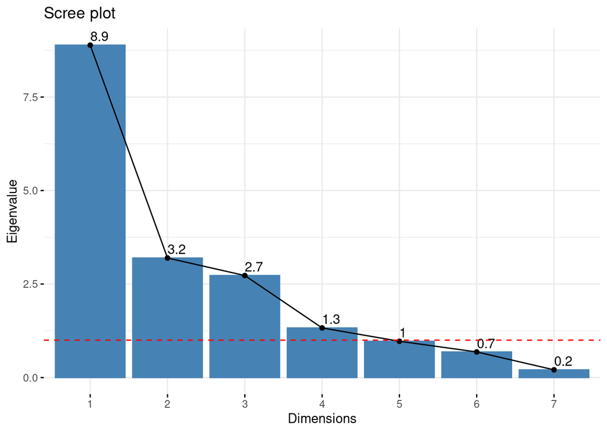

```r
library(factoextra)
fviz_eig(A,choice = "eigenvalue", addlabels = TRUE )+
geom_hline (yintercept = 1, linetype = 2, color = "red")
```

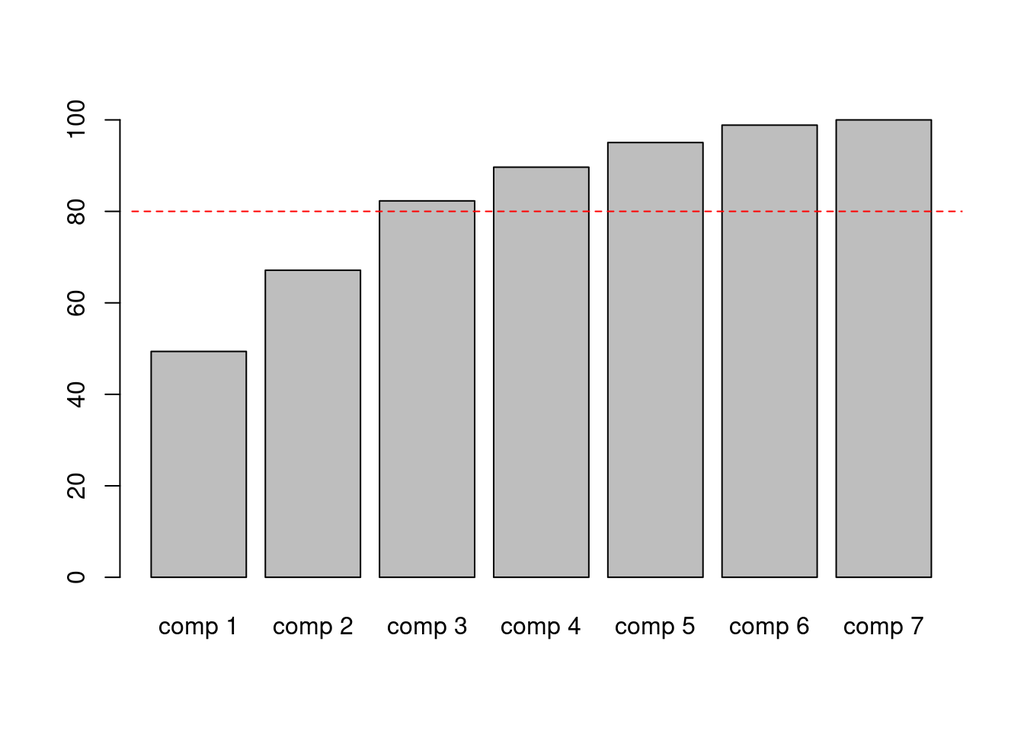

```
## numeric(0)
```

```r
barplot(A$eig[,3]) +
lines(c(0,20),c(80,80),type = "l", lty=2,col="red")
```

```r
kable(A$var$coord[,1:3], format="markdown", caption = "coord")
```

coord

|  | Dim.1 | Dim.2 | Dim.3 |
| --- | --- | --- | --- |
| CHMPAGNE | 0.6072688 | 0.1024555 | -0.5041422 |
| MOUSSEAU_AOC | 0.7775888 | 0.2470758 | -0.0814971 |
| MOUSSEAU_SIMPLE | 0.8021424 | 0.3733386 | -0.4236510 |
| ALSACE | 0.5591280 | 0.8134794 | 0.0078692 |
| GIRONDE | 0.9448574 | -0.2172973 | 0.1820483 |
| BOJOLAIS | 0.8234525 | 0.4984034 | -0.0819653 |
| BORDEAUX | 0.4479770 | -0.1548469 | -0.4511489 |
| RHON | 0.5193233 | -0.0518218 | 0.5809746 |
| ANJOU | 0.8057605 | -0.4599190 | -0.3146331 |
| AOC_AUTRES | 0.8500064 | -0.1539469 | 0.4599846 |
| VDQS | 0.8948636 | -0.2799860 | -0.0775227 |
| AUTRE_VDQS | 0.7475147 | 0.5065459 | -0.2339489 |
| PROVENCE | 0.6127968 | 0.6676495 | 0.3491175 |
| MUSCAT | 0.6967702 | -0.6123740 | -0.1569654 |
| RHONE | 0.6271885 | 0.0377170 | 0.7099313 |
| AOC_FORT | 0.6995089 | -0.5985468 | -0.1479583 |
| AUTRE_FORT | 0.3001127 | -0.2669118 | 0.8028566 |
| TRES_FORT | 0.5935437 | -0.4236271 | -0.1342321 |

```r
#kable(A$var$cor[,1:3], format="markdown", caption = "cor")
kable(A$var$cos2[,1:3], format="markdown", caption = "cos2")
```

cos2

|  | Dim.1 | Dim.2 | Dim.3 |
| --- | --- | --- | --- |
| CHMPAGNE | 0.3687753 | 0.0104971 | 0.2541593 |
| MOUSSEAU_AOC | 0.6046444 | 0.0610465 | 0.0066418 |
| MOUSSEAU_SIMPLE | 0.6434325 | 0.1393817 | 0.1794802 |
| ALSACE | 0.3126241 | 0.6617487 | 0.0000619 |
| GIRONDE | 0.8927555 | 0.0472181 | 0.0331416 |
| BOJOLAIS | 0.6780740 | 0.2484060 | 0.0067183 |
| BORDEAUX | 0.2006834 | 0.0239776 | 0.2035353 |
| RHON | 0.2696967 | 0.0026855 | 0.3375315 |
| ANJOU | 0.6492500 | 0.2115255 | 0.0989940 |
| AOC_AUTRES | 0.7225110 | 0.0236996 | 0.2115859 |
| VDQS | 0.8007809 | 0.0783922 | 0.0060098 |
| AUTRE_VDQS | 0.5587782 | 0.2565887 | 0.0547321 |
| PROVENCE | 0.3755199 | 0.4457558 | 0.1218830 |
| MUSCAT | 0.4854887 | 0.3750019 | 0.0246381 |
| RHONE | 0.3933654 | 0.0014226 | 0.5040025 |
| AOC_FORT | 0.4893127 | 0.3582583 | 0.0218917 |
| AUTRE_FORT | 0.0900676 | 0.0712419 | 0.6445787 |
| TRES_FORT | 0.3522942 | 0.1794599 | 0.0180183 |

```r
kable(A$var$contrib[,1:3], format="markdown", caption = "contrib")
```

contrib

|  | Dim.1 | Dim.2 | Dim.3 |
| --- | --- | --- | --- |
| CHMPAGNE | 4.149112 | 0.3284142 | 9.3180435 |
| MOUSSEAU_AOC | 6.802888 | 1.9099057 | 0.2435024 |
| MOUSSEAU_SIMPLE | 7.239295 | 4.3607099 | 6.5801421 |
| ALSACE | 3.517351 | 20.7035354 | 0.0022703 |
| GIRONDE | 10.044443 | 1.4772708 | 1.2150433 |
| BOJOLAIS | 7.629049 | 7.7716548 | 0.2463081 |
| BORDEAUX | 2.257900 | 0.7501644 | 7.4620561 |
| RHON | 3.034373 | 0.0840188 | 12.3746523 |
| ANJOU | 7.304749 | 6.6178071 | 3.6293383 |
| AOC_AUTRES | 8.129012 | 0.7414696 | 7.7572063 |
| VDQS | 9.009631 | 2.4525853 | 0.2203312 |
| AUTRE_VDQS | 6.286845 | 8.0276606 | 2.0066004 |
| PROVENCE | 4.224996 | 13.9459616 | 4.4685023 |
| MUSCAT | 5.462260 | 11.7323468 | 0.9032883 |
| RHONE | 4.425776 | 0.0445068 | 18.4778464 |
| AOC_FORT | 5.505284 | 11.2085054 | 0.8025964 |
| AUTRE_FORT | 1.013356 | 2.2288810 | 23.6316826 |
| TRES_FORT | 3.963681 | 5.6146018 | 0.6605896 |

## Interprétation

Axe 1 : forte contribution : Gironde, VDQS, AOC_Autres fort cos2->mieux représenté : Gironde, VDQS, AOC_Autres toute les coordonnées sont positives ->effet taille car toutes les coords sont positives

Axe2 : forte contribution: Alsace, Muscat, AOC_Fort, Provence fort cos2 : Alsace et Provence coord: Alsace et Provence positifs, opposé au muscat

Axe3: forte contrib : Rhon, Rhone, Autre_Fort fort cos2:Autre_Fort et Rhone coord : les 3 sont positives

#### i. par rapport aux composantes principales 1 et 2 et analyser le graphique

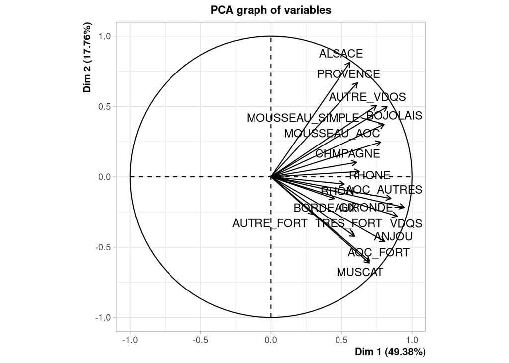

```r
plot.PCA(A, axes=c(1,2), choix="var")
```

#### ii. par rapport aux composantes principales 1 et 3 et analyser le graphique

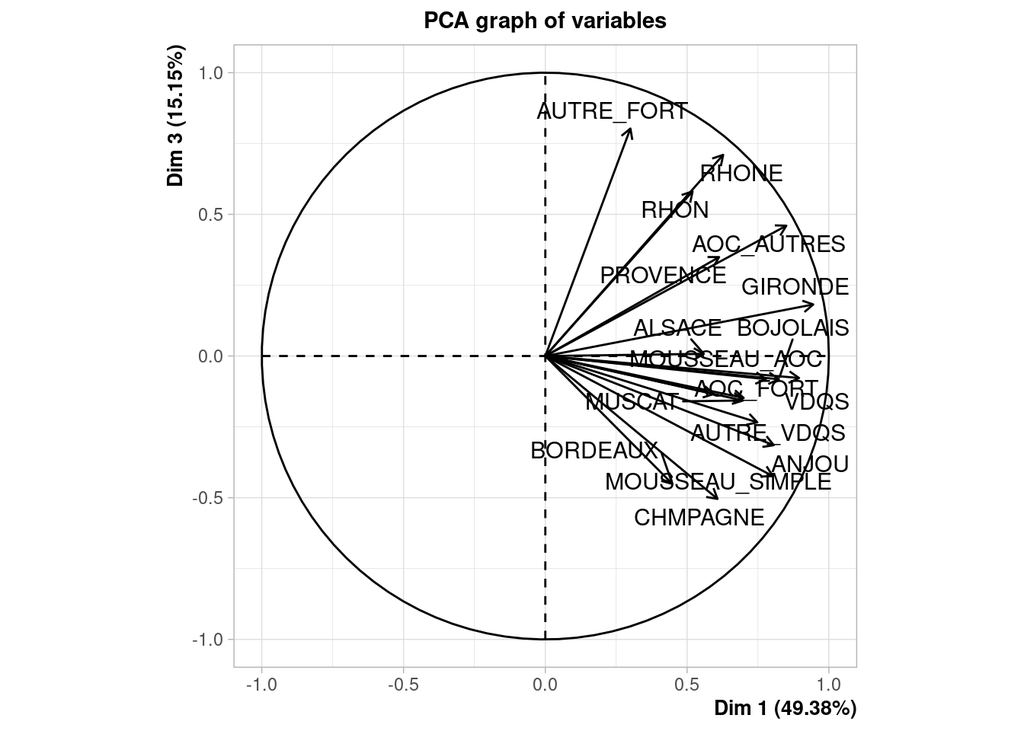

```r
plot.PCA(A, axes=c(1,3), choix="var")
```

### h. Représentation de la répartition des pays par rapport aux composantes principales 1 et 2 et analyser le graphique.

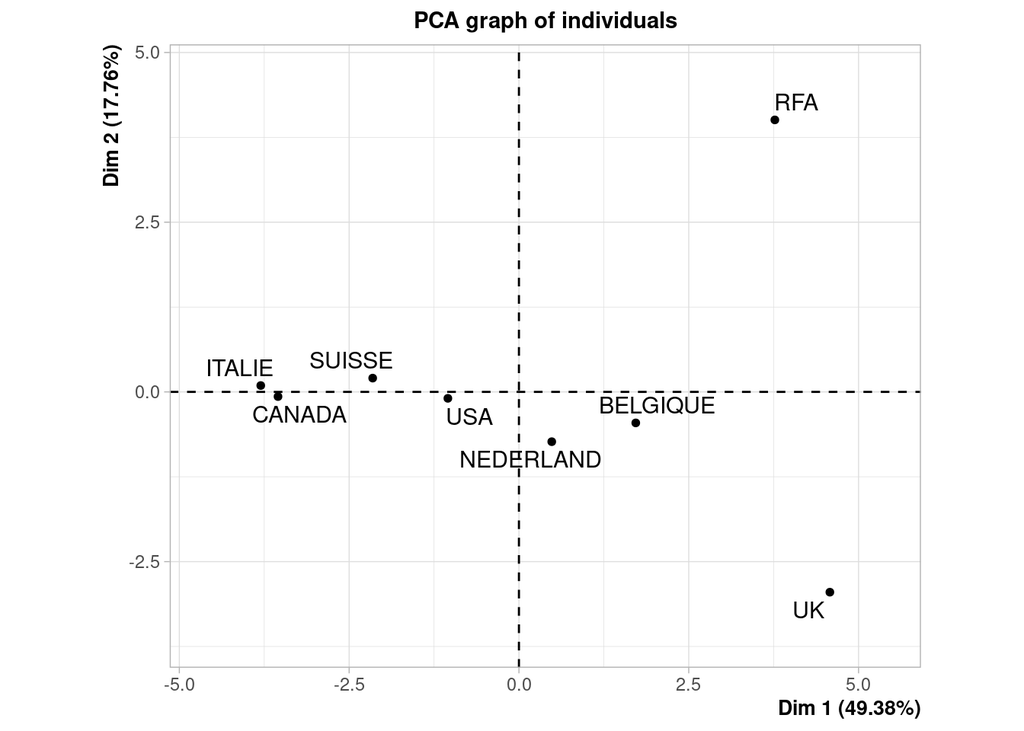

```r
plot.PCA(A, axes=c(1,2), choix="ind")
```

### Interprétation:

Axe 1 :Oppose UK et RFA à Italie, Canada et Suisse Oppose les pays qui consomment beaucoup de vins à ceux qui en consomment peu

Axe2 : Oppose UK et RFA RFA consomme beaucoup de vins d’Alsace et de Provence, tandis que UK consomme plutot du muscat

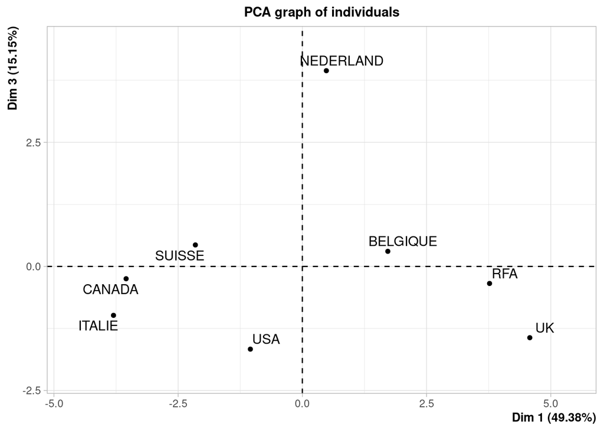

```r
plot.PCA(A, axes=c(1,3), choix="ind")
```

### Interprétation:

Axe 1 :Oppose UK et RFA à Italie, Canada et Suisse Oppose les pays qui consomment beaucoup de vins à ceux qui en consomment peu

Axe3 : Oppose Nederland à Italie, USA et UK

## Classification ascendante hierarchique

```r
CAH=HCPC(A, nb.clust=-1, graph=FALSE)
CAH$data.clust$clust
```

```
## [1] 2 2 3 1 4 1 1 1
## Levels: 1 2 3 4
```

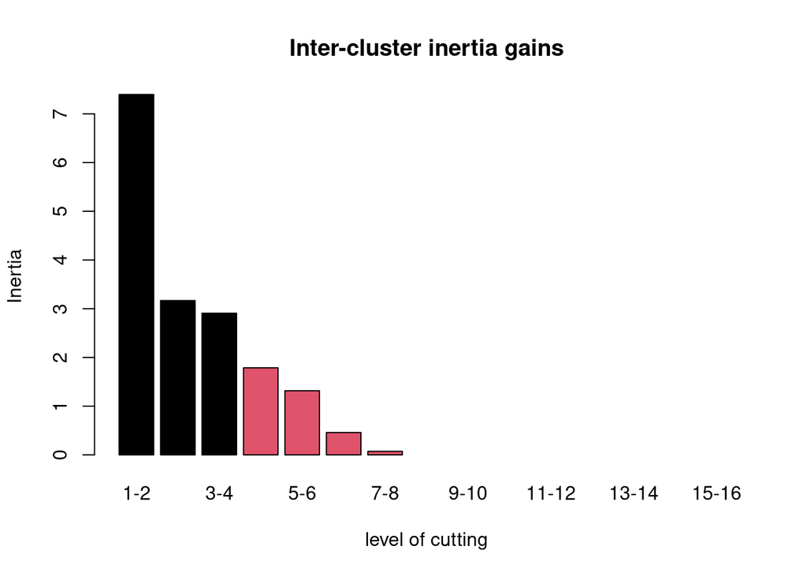

```r
plot(CAH, choice="bar")
```

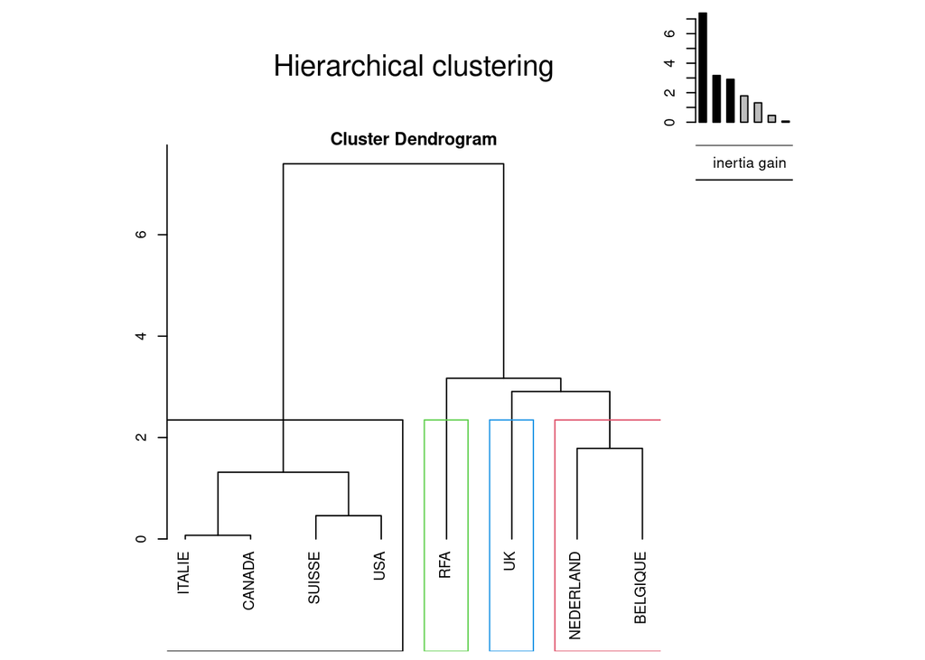

```r
plot(CAH, choice="tree")
```

# 3. Caractériser chaque classe à l’aide des composantes principales utilisées

```r
CAH$desc.axes
```

```
##
## Link between the cluster variable and the quantitative variables
## ================================================================
##            Eta2      P-value
## Dim.2 0.9961834 2.727729e-05
## Dim.1 0.9196585 1.177350e-02
##
## Description of each cluster by quantitative variables
## =====================================================
## $`1`
##          v.test Mean in category Overall mean sd in category Overall sd
## Dim.1 -2.340252        -2.637042 3.538836e-16        1.11217   2.981284
##          p.value
## Dim.1 0.01927072
##
## $`2`
##         v.test Mean in category Overall mean sd in category Overall sd
## Dim.3 1.964184         2.123658 6.106227e-16       1.819675   1.651546
##          p.value
## Dim.3 0.04950871
##
## $`3`
##         v.test Mean in category  Overall mean sd in category Overall sd p.value
## Dim.2 2.241248         4.006953 -1.960238e-16              0   1.787822 0.02501
##
## $`4`
## NULL
```

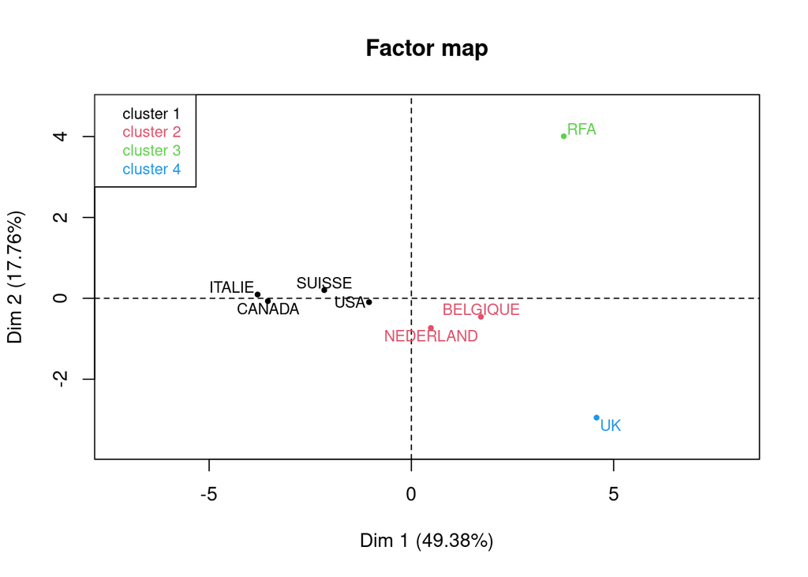

```r
plot(CAH, choice="map", draw.tree = F)
```

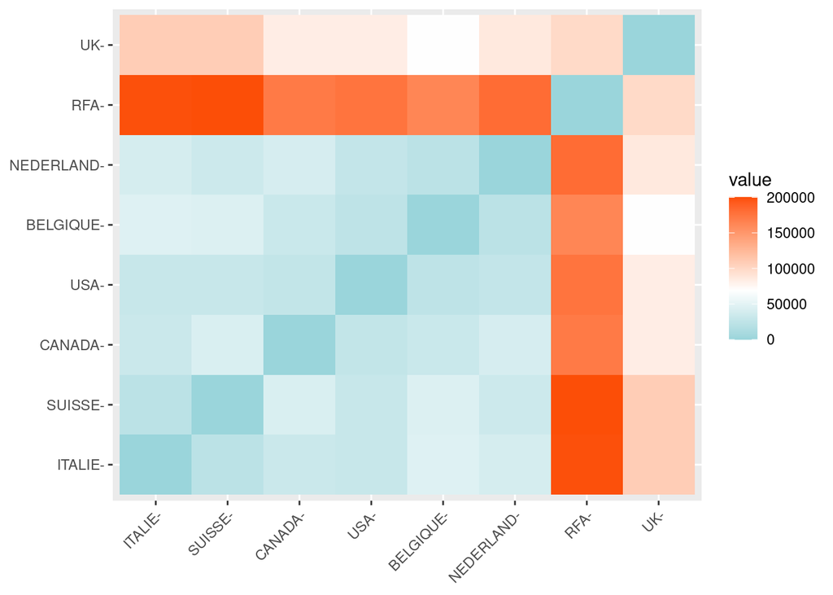

```r
distance <- get_dist(d)
fviz_dist(distance, gradient = list(low = "#00AFBB", mid = "white", high = "#FC4E07"))
```

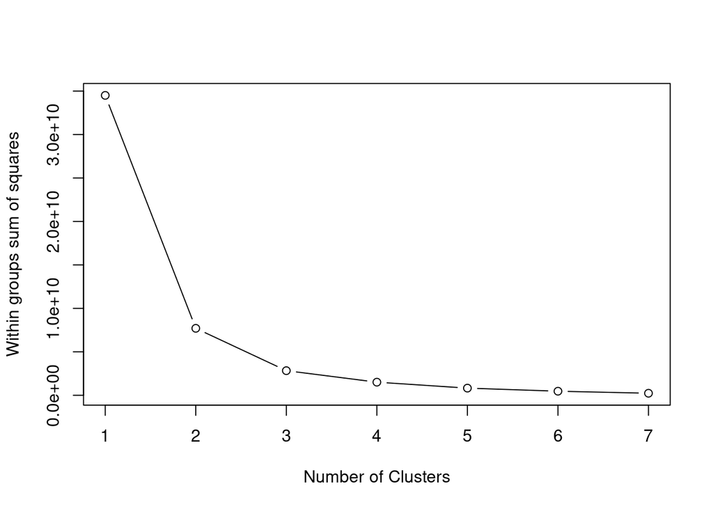

```r
# 2. Choix du nombre de clusters (K) - Exemple avec la méthode du coude
wss <- numeric(7)  # Pour stocker la somme des carrés des distances
for (i in 1:7) {
  wss[i] <- sum(kmeans(d, centers = i)$withinss)
}
plot(1:7, wss, type = "b", xlab = "Number of Clusters",
     ylab = "Within groups sum of squares")
```

```r
k2 <- kmeans(d, centers = 2, nstart = 25)
```